# IODS course project

## Exercise 6:

First let’s load the tea dataset from the package Factominer.

```r
library(FactoMineR)
data(tea)
head(tea)
```

```
##       breakfast     tea.time     evening     lunch     dinner     always
## 1     breakfast Not.tea time Not.evening Not.lunch Not.dinner Not.always
## 2     breakfast Not.tea time Not.evening Not.lunch Not.dinner Not.always
## 3 Not.breakfast     tea time     evening Not.lunch     dinner Not.always
## 4 Not.breakfast Not.tea time Not.evening Not.lunch     dinner Not.always
## 5     breakfast Not.tea time     evening Not.lunch Not.dinner     always
## 6 Not.breakfast Not.tea time Not.evening Not.lunch     dinner Not.always
##   home     work     tearoom     friends     resto     pub       Tea   How
## 1 home Not.work Not.tearoom Not.friends Not.resto Not.pub     black alone
## 2 home Not.work Not.tearoom Not.friends Not.resto Not.pub     black  milk
## 3 home     work Not.tearoom     friends     resto Not.pub Earl Grey alone
## 4 home Not.work Not.tearoom Not.friends Not.resto Not.pub Earl Grey alone
## 5 home Not.work Not.tearoom Not.friends Not.resto Not.pub Earl Grey alone
## 6 home Not.work Not.tearoom Not.friends Not.resto Not.pub Earl Grey alone
##      sugar     how       where           price age sex          SPC
```

[output cut: 34 more lines]

```r
str(tea)
```

```
## 'data.frame':    300 obs. of  36 variables:
##  $ breakfast       : Factor w/ 2 levels "breakfast","Not.breakfast": 1 1 2 2 1 2 1 2 1 1 ...
##  $ tea.time        : Factor w/ 2 levels "Not.tea time",..: 1 1 2 1 1 1 2 2 2 1 ...
##  $ evening         : Factor w/ 2 levels "evening","Not.evening": 2 2 1 2 1 2 2 1 2 1 ...
##  $ lunch           : Factor w/ 2 levels "lunch","Not.lunch": 2 2 2 2 2 2 2 2 2 2 ...
##  $ dinner          : Factor w/ 2 levels "dinner","Not.dinner": 2 2 1 1 2 1 2 2 2 2 ...
##  $ always          : Factor w/ 2 levels "always","Not.always": 2 2 2 2 1 2 2 2 2 2 ...
##  $ home            : Factor w/ 2 levels "home","Not.home": 1 1 1 1 1 1 1 1 1 1 ...
##  $ work            : Factor w/ 2 levels "Not.work","work": 1 1 2 1 1 1 1 1 1 1 ...
##  $ tearoom         : Factor w/ 2 levels "Not.tearoom",..: 1 1 1 1 1 1 1 1 1 2 ...
##  $ friends         : Factor w/ 2 levels "friends","Not.friends": 2 2 1 2 2 2 1 2 2 2 ...
##  $ resto           : Factor w/ 2 levels "Not.resto","resto": 1 1 2 1 1 1 1 1 1 1 ...
##  $ pub             : Factor w/ 2 levels "Not.pub","pub": 1 1 1 1 1 1 1 1 1 1 ...
##  $ Tea             : Factor w/ 3 levels "black","Earl Grey",..: 1 1 2 2 2 2 2 1 2 1 ...
##  $ How             : Factor w/ 4 levels "alone","lemon",..: 1 3 1 1 1 1 1 3 3 1 ...
```

[output cut: 22 more lines]

```r
dim(tea)
```

```
## [1] 300  36
```

```r
summary(tea)
```

```
##          breakfast           tea.time          evening          lunch
##  breakfast    :144   Not.tea time:131   evening    :103   lunch    : 44
##  Not.breakfast:156   tea time    :169   Not.evening:197   Not.lunch:256
##
##
##
##
##
##         dinner           always          home           work
##  dinner    : 21   always    :103   home    :291   Not.work:213
##  Not.dinner:279   Not.always:197   Not.home:  9   work    : 87
##
##
##
##
##
##         tearoom           friends          resto          pub
##  Not.tearoom:242   friends    :196   Not.resto:221   Not.pub:237
##  tearoom    : 58   Not.friends:104   resto    : 79   pub    : 63
##
##
##
##
##
##         Tea         How           sugar                     how
##  black    : 74   alone:195   No.sugar:155   tea bag           :170
##  Earl Grey:193   lemon: 33   sugar   :145   tea bag+unpackaged: 94
##  green    : 33   milk : 63                  unpackaged        : 36
##                  other:  9
##
##
##
##                   where                 price          age        sex
##  chain store         :192   p_branded      : 95   Min.   :15.00   F:178
##  chain store+tea shop: 78   p_cheap        :  7   1st Qu.:23.00   M:122
##  tea shop            : 30   p_private label: 21   Median :32.00
##                             p_unknown      : 12   Mean   :37.05
##                             p_upscale      : 53   3rd Qu.:48.00
##                             p_variable     :112   Max.   :90.00
##
```

[output cut: 25 more lines]

```
##  feminine    :129   Not.sophisticated: 85   No.slimming:255
##  Not.feminine:171   sophisticated    :215   slimming   : 45
##
##
##
##
##
##         exciting          relaxing              effect.on.health
##  exciting   :116   No.relaxing:113   effect on health   : 66
##  No.exciting:184   relaxing   :187   No.effect on health:234
##
##
##
##
##
```

The data has 300 observations and 36 variables, most of them factor variables, for example whether one has had breakfast or not, or tea time or not, what kind of tea they drink, whether they use sugar or not etc.

Let’s select some relevant varables (my computer cannot handle the entire data) and visualise the data.

```r
library(tidyr)
keep_columns<-c("breakfast","lunch","dinner","work","tearoom","friends","pub")
tea2<-select(tea,one_of(keep_columns))
summary(tea2)
```

```
##          breakfast         lunch            dinner          work
##  breakfast    :144   lunch    : 44   dinner    : 21   Not.work:213
##  Not.breakfast:156   Not.lunch:256   Not.dinner:279   work    : 87
##         tearoom           friends         pub
##  Not.tearoom:242   friends    :196   Not.pub:237
##  tearoom    : 58   Not.friends:104   pub    : 63
```

```r
str(tea2)
```

```
## 'data.frame':    300 obs. of  7 variables:
##  $ breakfast: Factor w/ 2 levels "breakfast","Not.breakfast": 1 1 2 2 1 2 1 2 1 1 ...
##  $ lunch    : Factor w/ 2 levels "lunch","Not.lunch": 2 2 2 2 2 2 2 2 2 2 ...
##  $ dinner   : Factor w/ 2 levels "dinner","Not.dinner": 2 2 1 1 2 1 2 2 2 2 ...
##  $ work     : Factor w/ 2 levels "Not.work","work": 1 1 2 1 1 1 1 1 1 1 ...
##  $ tearoom  : Factor w/ 2 levels "Not.tearoom",..: 1 1 1 1 1 1 1 1 1 2 ...
##  $ friends  : Factor w/ 2 levels "friends","Not.friends": 2 2 1 2 2 2 1 2 2 2 ...
##  $ pub      : Factor w/ 2 levels "Not.pub","pub": 1 1 1 1 1 1 1 1 1 1 ...
```

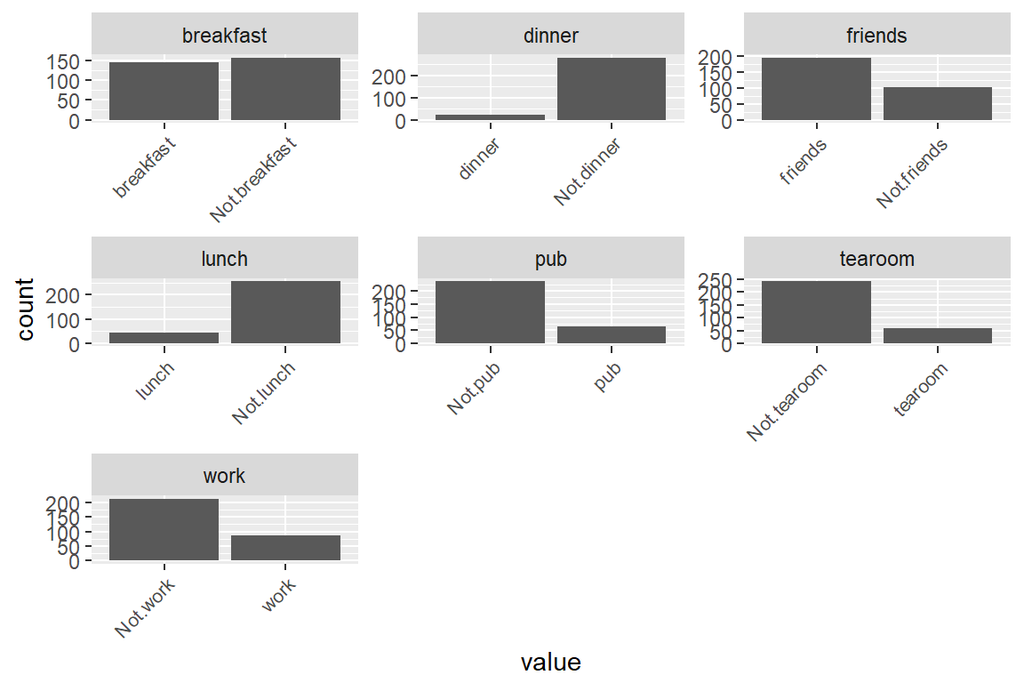

```r
library(ggplot2)
gather(tea2)%>%ggplot(aes(value))+facet_wrap("key",scales="free")+geom_bar()+theme(axis.text.x = element_text(angle = 45,hjust = 1,size = 8))
```

Then let’s do Multiple Correspondence Analysis on the selected data.

```r
mca_tea<-MCA(tea2)
```

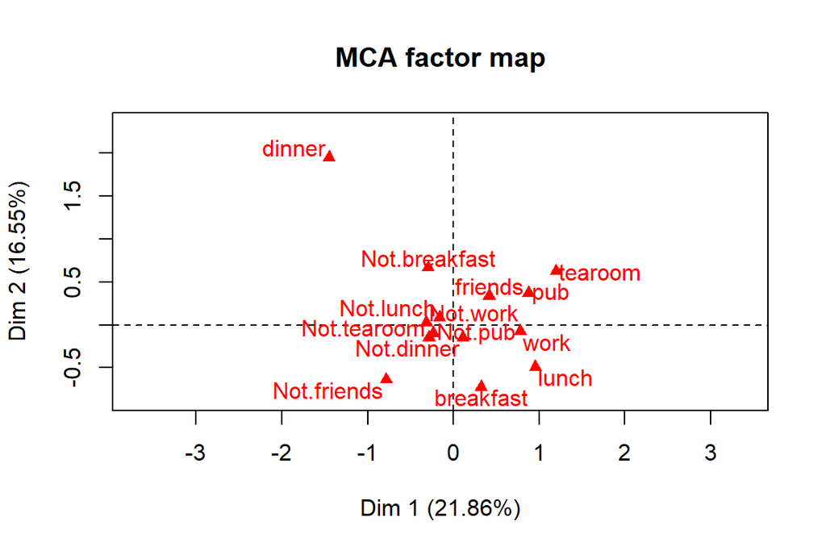

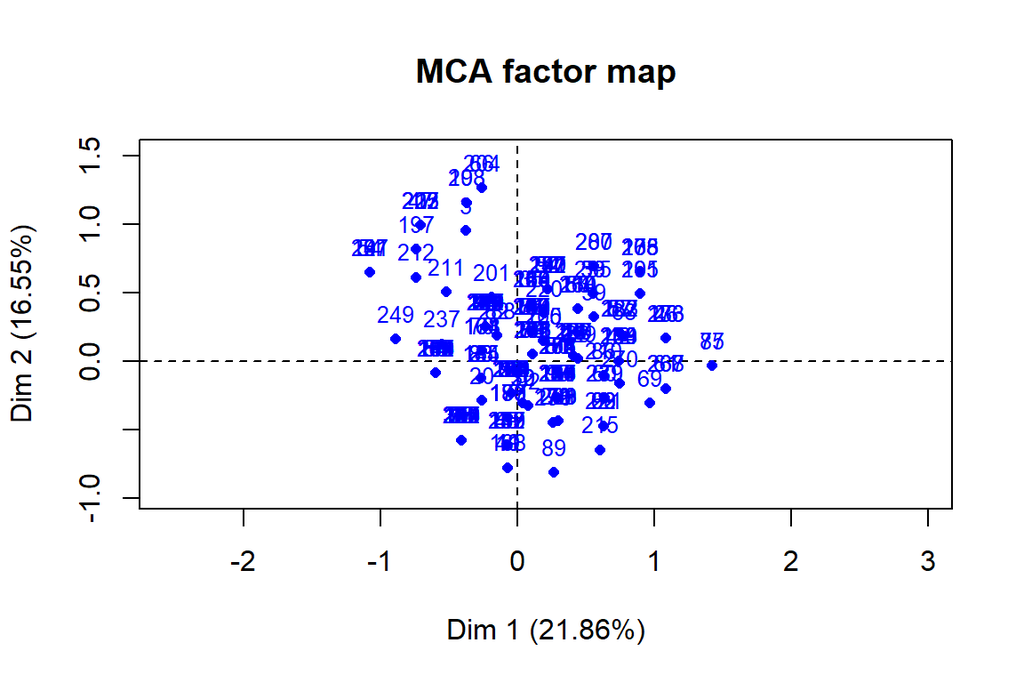

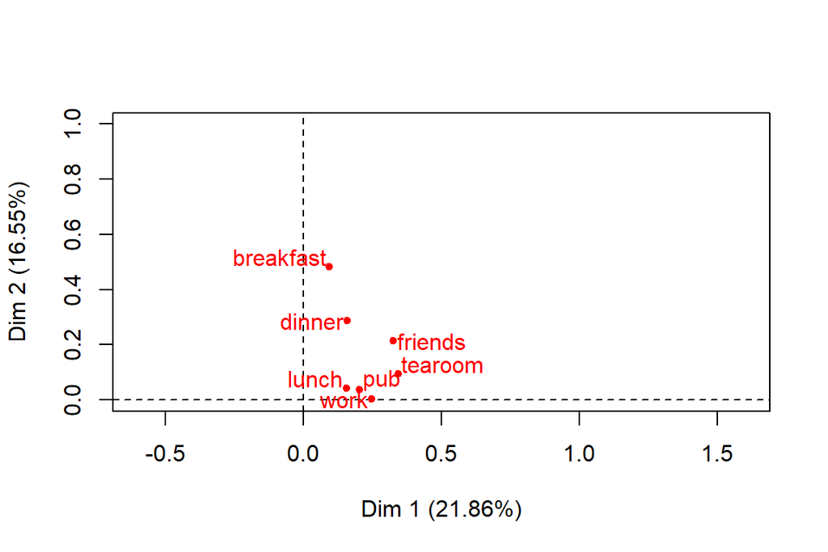

```r
summary(mca_tea)
```

```
##
## Call:
## MCA(X = tea2)
##
##
## Eigenvalues
##                        Dim.1   Dim.2   Dim.3   Dim.4   Dim.5   Dim.6
## Variance               0.219   0.165   0.148   0.133   0.123   0.113
## % of var.             21.862  16.547  14.831  13.255  12.305  11.325
## Cumulative % of var.  21.862  38.409  53.240  66.496  78.801  90.126
##                        Dim.7
## Variance               0.099
## % of var.              9.874
## Cumulative % of var. 100.000
##
## Individuals (the 10 first)
##                  Dim.1    ctr   cos2    Dim.2    ctr   cos2    Dim.3
## 1             | -0.414  0.261  0.291 | -0.576  0.669  0.563 |  0.230
## 2             | -0.414  0.261  0.291 | -0.576  0.669  0.563 |  0.230
## 3             | -0.378  0.218  0.056 |  0.955  1.836  0.357 | -0.039
## 4             | -1.080  1.777  0.475 |  0.649  0.849  0.172 |  0.147
## 5             | -0.414  0.261  0.291 | -0.576  0.669  0.563 |  0.230
## 6             | -1.080  1.777  0.475 |  0.649  0.849  0.172 |  0.147
## 7             | -0.047  0.003  0.006 | -0.234  0.110  0.138 | -0.042
## 8             | -0.603  0.554  0.641 | -0.088  0.016  0.014 |  0.007
## 9             | -0.414  0.261  0.291 | -0.576  0.669  0.563 |  0.230
## 10            |  0.039  0.002  0.001 | -0.304  0.186  0.080 |  0.516
##                  ctr   cos2
## 1              0.119  0.090 |
## 2              0.119  0.090 |
## 3              0.003  0.001 |
## 4              0.048  0.009 |
## 5              0.119  0.090 |
## 6              0.048  0.009 |
## 7              0.004  0.004 |
## 8              0.000  0.000 |
## 9              0.119  0.090 |
## 10             0.598  0.231 |
##
## Categories (the 10 first)
```

[output cut: 17 more lines]

```
## Not.dinner     -9.264 |  -0.026   0.062   0.009  -1.658 |
## Not.work        0.819 |  -0.067   0.311   0.011  -1.825 |
## work           -0.819 |   0.165   0.762   0.011   1.825 |
## Not.tearoom    -5.298 |  -0.149   1.720   0.092  -5.255 |
## tearoom         5.298 |   0.621   7.176   0.092   5.255 |
##
## Categorical variables (eta2)
##                 Dim.1 Dim.2 Dim.3
## breakfast     | 0.095 0.482 0.090 |
## lunch         | 0.156 0.041 0.519 |
## dinner        | 0.159 0.287 0.009 |
## work          | 0.248 0.002 0.011 |
## tearoom       | 0.343 0.094 0.092 |
## friends       | 0.326 0.215 0.122 |
## pub           | 0.204 0.037 0.194 |
```

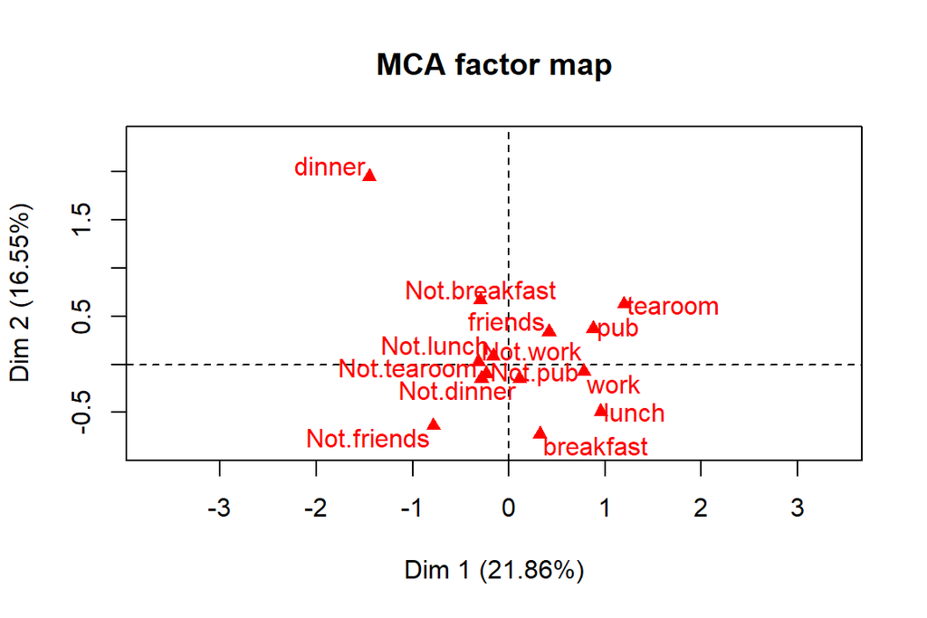

```r
plot(mca_tea,invisible=c("ind"))
```

From the results we can infer many things. For example having breakfast and lunch seem to go together. Having dinner seems to be different from other selected habbits etc.

```r
library(factoextra)
```

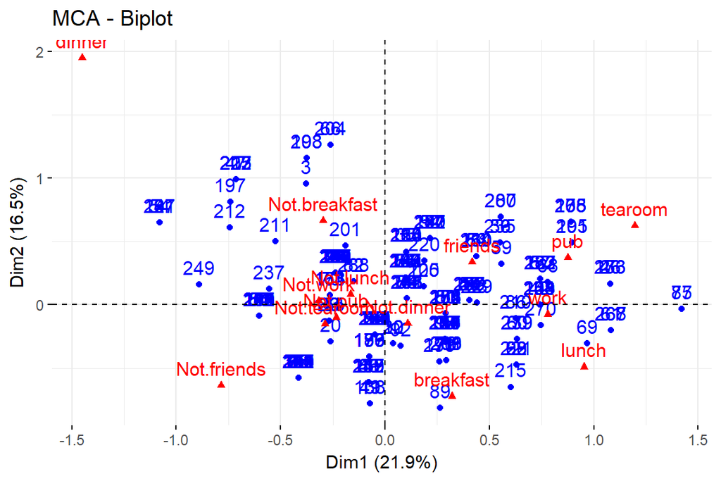

```r
fviz_mca_biplot(mca_tea)
```

The biplot seems to give similiar results as privious visualizations.